# Correlación entre las variables

Sergio Martí

2023-03-16

## Correlación entre las variables

Se va a realizar un análisis de correlación entre las variables cuantitativas. Las variables no están en las mismas unidades, por lo tanto, antes de calcular la matriz de correlación, la cual se calcula con la función `cor()`, se deben de escalar los datos con la función `scale()`. Esta función tipifica los datos (es decir, resta la media y divide por la desviación típica). Esta transformación ayuda a reducir el efecto de la escala de las variables.

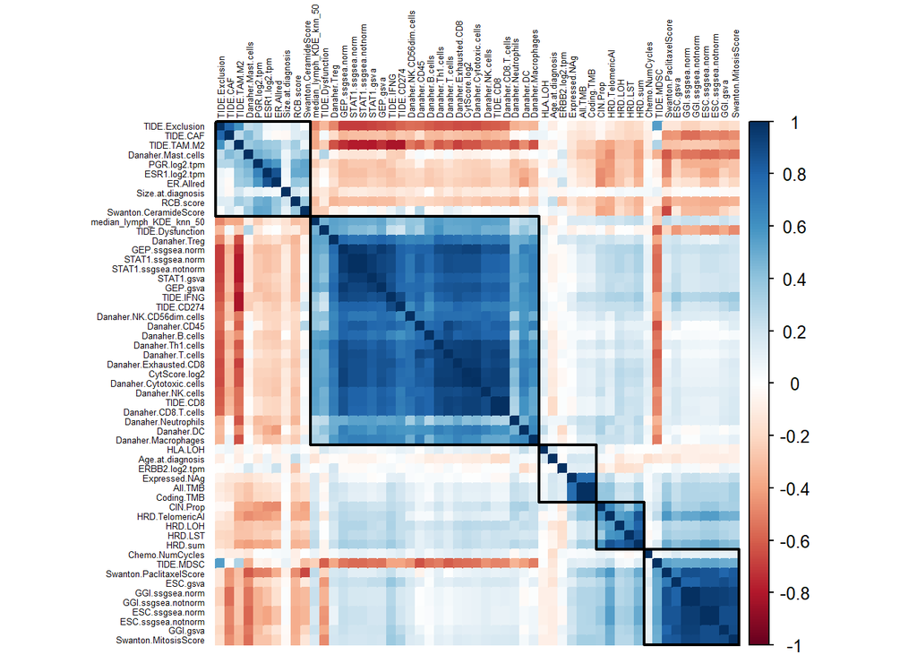

```r
# Cargar los datos
dfClinical <- readRDS("./dfClinical.RDS")
numVars <- readRDS("./numVars.RDS")

# Calcular la matriz de correlación
mCor <- cor(scale(numVars))

# Librería para graficar la matriz de correlaciones
library(corrplot)
# Gráfica de la matriz de correlación
corrplot(mCor, method = "color",
         order = "hclust",
         addrect = 5,
         type = "full",
         diag = TRUE,
         tl.col = "black",
         tl.cex = 0.4)
```

Tras calcular la matriz de correlación, se ejecuta la función `findCorrelation()`. Realiza una búsqueda en la matriz para encontrar aquellas variables cuya media de correlación en valor absoluto es mayor a un cierto valor elegido (*threshold*). Esta función se encuentra dentro del paquete `caret`.

```r
library(caret) # Contiene la función findCorrelation
# Obtener las variables más correlacionadas
lVarDrop <- findCorrelation(mCor, cutoff = 0.9)

# Mostramos las variables altamente correlacionadas:
sprintf("Número de variables altamente correlacionadas: %d", length(lVarDrop))
```

```
## [1] "Número de variables altamente correlacionadas: 16"
```

```r
colnames(numVars[lVarDrop])
```

```
##  [1] "GEP.ssgsea.norm"         "STAT1.ssgsea.notnorm"
##  [3] "STAT1.ssgsea.norm"       "GEP.gsva"
##  [5] "Danaher.Exhausted.CD8"   "Danaher.Cytotoxic.cells"
##  [7] "CytScore.log2"           "Danaher.Th1.cells"
##  [9] "Danaher.T.cells"         "TIDE.CD8"
## [11] "Swanton.MitosisScore"    "ESC.ssgsea.notnorm"
## [13] "ESC.ssgsea.norm"         "GGI.gsva"
## [15] "GGI.ssgsea.notnorm"      "Coding.TMB"
```

## Análisis de componentes principales

Se va a realizar un análisis de componentes principales para comprobar si hay separabilidad entre los grupos de pacientes clasificados según la respuesta al tratamiento (**RCB.category**).

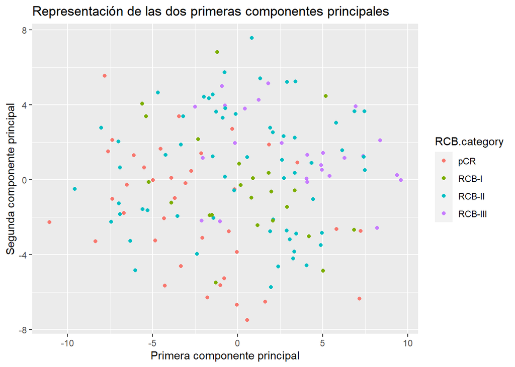

```r
# Calcular las componentes principales
pca <- prcomp(numVars, scale = TRUE)

# Construir la variable RCB.category como un factor con sus correspondientes niveles
lCategory <- as.factor(dfClinical$RCB.category)
levels(lCategory) <- c("pCR", "RCB-I", "RCB-II", "RCB-III")

# Añadir la columna del factor
dfPCA <- data.frame(pca$x[,1:2])
dfPCA <- cbind(dfPCA, RCB.category=lCategory)

# La variable lCategory ya no es necesaria
rm(lCategory)

# Graficar el resultado en un gráfico de dispersion
ggplot2::ggplot(dfPCA, aes(PC1, PC2)) +
  ggplot2::geom_point(aes(color=RCB.category)) +
  ggplot2::xlab("Primera componente principal") +
  ggplot2::ylab("Segunda componente principal") +
  ggplot2::ggtitle("Representación de las dos primeras componentes principales")
```

A primera vista, realizando un PCA, no se aprecia separabilidad entre los grupos.